# Introduction to Machine Learning - Part 3

Random Forest

Gladstone Bioinformatics Core

2026-01-12

# Introduction to Random Forest

Random Forest is an **ensemble method** that builds many decision trees (models that make predictions using if-then rules) and combines their predictions.

Two sources of randomness make trees diverse:  
1. **Bootstrap sampling**: Each tree trained on random subset of data  
2. **Feature sampling**: Each split considers random subset of features

This diversity reduces overfitting and improves predictions!

# Load Libraries and Data

```r
# Core libraries
library(tidyverse)
library(caret)
library(randomForest)
library(ggplot2)

# Set seed for reproducibility
set.seed(321)
```

```r
# Load the cleaned dataset from Part 1
covid_ml <- read.csv("data/covid_ml_clean.csv")

# Convert target to factor
covid_ml$covid19_test_results <- as.factor(covid_ml$covid19_test_results)

# Remove cough_severity_encoded - Random Forest can handle categorical variables directly
# We'll use the original cough_severity (categorical) instead
covid_ml <- covid_ml %>%
  select(-cough_severity_encoded)

# Ensure cough_severity is a factor
covid_ml$cough_severity <- as.factor(covid_ml$cough_severity)
```

**Note:** Random Forest can handle categorical variables directly, so we use the original `cough_severity` (categorical) rather than `cough_severity_encoded` (numeric). This is one advantage of tree-based methods - they can work with mixed data types without encoding!

# Prepare Data

## Check Class Distribution

First, let’s examine the class distribution to identify any imbalance:

```r
# Check class distribution
class_dist <- table(covid_ml$covid19_test_results)
print(class_dist)
```

```
##
## Negative Positive
##     2977       68
```

```r
cat("\nClass proportions:\n")
```

```
##
## Class proportions:
```

```r
prop.table(class_dist)
```

```
##
##   Negative   Positive
## 0.97766831 0.02233169
```

**Class Imbalance Problem:**  
With only 68 positives out of 3045 rows (~2.2%), the model might learn to always predict “Negative” and still achieve high accuracy. This is problematic because we care about correctly identifying positive cases!

## Balanced Train-Test Split

To handle class imbalance, we’ll use **balanced sampling** for training:  
- **Training set**: Randomly select 50 positive and 50 negative cases (balanced)  
- **Test set**: Use all remaining data (maintains original class distribution)

This approach helps the model learn from both classes equally during training.

```r
# Separate data by class
positive_indices <- which(covid_ml$covid19_test_results == "Positive")
negative_indices <- which(covid_ml$covid19_test_results == "Negative")

cat("Total positive cases:", length(positive_indices), "\n")
```

```
## Total positive cases: 68
```

```r
cat("Total negative cases:", length(negative_indices), "\n")
```

```
## Total negative cases: 2977
```

```r
# Randomly sample 50 from each class for training
set.seed(123)  # For reproducibility
train_positive_indices <- sample(positive_indices, min(50, length(positive_indices)))
train_negative_indices <- sample(negative_indices, 50)

# Combine training indices
train_indices <- c(train_positive_indices, train_negative_indices)

# Create balanced training set
train_data <- covid_ml[train_indices, ]

# Create test set with remaining data
test_data <- covid_ml[-train_indices, ]

# Shuffle training data (optional, but good practice)
train_data <- train_data[sample(nrow(train_data)), ]

cat("\nTraining set:")
```

```
##
## Training set:
```

```r
print(table(train_data$covid19_test_results))
```

```
##
## Negative Positive
##       50       50
```

```r
cat("\nTest set:")
```

```
##
## Test set:
```

```r
print(table(test_data$covid19_test_results))
```

```
##
## Negative Positive
##     2927       18
```

```r
cat("\nTraining set size:", nrow(train_data), "\n",
    "Test set size:", nrow(test_data), "\n")
```

```
##
## Training set size: 100
##  Test set size: 2945
```

**Why Balanced Training?**  
- Prevents the model from being biased toward the majority class  
- Forces the model to learn patterns from both classes  
- Test set maintains original distribution, giving realistic performance estimates

**Note:** Unlike some other algorithms, we don’t need to scale features for Random Forest! Tree-based methods are invariant to monotonic transformations of features. Additionally, Random Forest can handle categorical variables directly (like `cough_severity`) without needing to encode them as numbers.

# Train a Simple Random Forest

```r
# Train a simple random forest
rf_simple <- randomForest(
  covid19_test_results ~ .,  # Predict target using all features
  data = train_data,
  ntree = 100,               # Number of trees
  importance = TRUE          # Calculate variable importance
)

# View the model summary
print(rf_simple)
```

```
##
## Call:
##  randomForest(formula = covid19_test_results ~ ., data = train_data,      ntree = 100, importance = TRUE)
##                Type of random forest: classification
##                      Number of trees: 100
## No. of variables tried at each split: 4
##
##         OOB estimate of  error rate: 38%
## Confusion matrix:
##          Negative Positive class.error
## Negative       33       17        0.34
## Positive       21       29        0.42
```

**Out-of-Bag (OOB) Error:** Random Forest uses bootstrap sampling, so ~37% of data is left out for each tree. These “out-of-bag” samples are used to estimate error without needing a separate validation set!

# Variable Importance

One of the best features of Random Forest is built-in variable importance!

## Mean Decrease Gini

This measures how much each variable contributes to the purity of nodes in the trees. Higher values = more important.

```r
# Get variable importance from our simple RF model
importance_df <- as.data.frame(importance(rf_simple))
importance_df$Variable <- rownames(importance_df)

# View importance metrics
head(importance_df)
```

```
##                                 Negative    Positive MeanDecreaseAccuracy
## temperature                    5.2564892  3.18461994            5.0476561
## high_risk_exposure_occupation -0.9867099 -1.96098539           -1.8342510
## high_risk_interactions        -0.2359255  0.16380375           -0.1632838
## labored_respiration            0.0000000  0.00000000            0.0000000
## rhonchi                        0.9197710  0.07857794            0.6562613
## cough                          4.6989976 -1.00352574            3.5952685
##                               MeanDecreaseGini                      Variable
## temperature                         10.4754692                   temperature
## high_risk_exposure_occupation        1.0218076 high_risk_exposure_occupation
## high_risk_interactions               1.1374716        high_risk_interactions
## labored_respiration                  0.2231149           labored_respiration
## rhonchi                              0.6063104                       rhonchi
## cough                                2.0345521                         cough
```

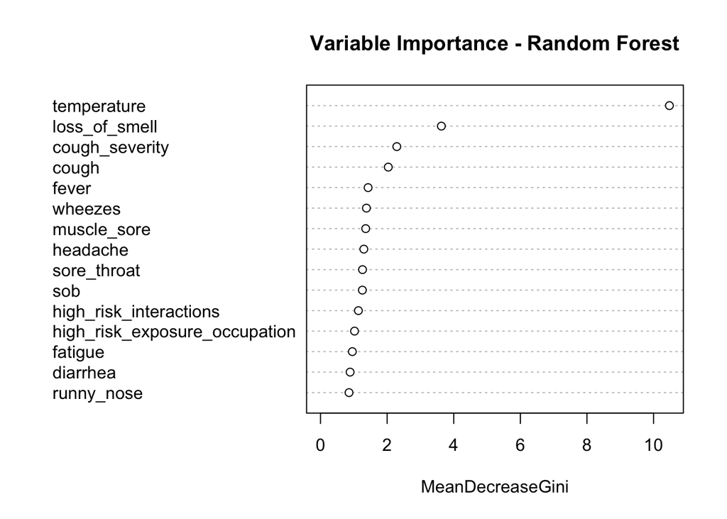

```r
# Plot variable importance
varImpPlot(rf_simple,
           type = 2,  # Mean Decrease Gini
           main = "Variable Importance - Random Forest",
           n.var = 15)
```

# Make Predictions

```r
# Get prediction probabilities first
rf_proba <- predict(rf_simple, newdata = test_data, type = "prob")
head(rf_proba)
```

```
##   Negative Positive
## 1     0.05     0.95
## 2     0.43     0.57
## 3     0.49     0.51
## 4     0.52     0.48
## 5     0.51     0.49
## 6     0.99     0.01
```

## Adjust Prediction Threshold

With severe class imbalance, the default threshold (0.5) often leads to too many false positives. We’ll use a **higher threshold** to be more conservative about positive predictions:

```r
# Higher threshold = more specific (fewer false positives, but may miss some positives)
# Lower threshold = more sensitive (catch more positives, but more false alarms)

# For imbalanced data, use a higher threshold to reduce false positives
threshold <- 0.7  # Classify as Positive only if probability > 0.7

rf_proba <- as.data.frame(rf_proba)
rf_predictions <- ifelse(rf_proba$Positive > threshold, "Positive", "Negative")
rf_predictions <- factor(rf_predictions, levels = c("Negative", "Positive"))

# Compare different thresholds
rf_predictions_default <- ifelse(rf_proba$Positive > 0.5, "Positive", "Negative")
rf_predictions_default <- factor(rf_predictions_default, levels = c("Negative", "Positive"))

cat("Default (0.5) - Positive predictions:", sum(rf_predictions_default == "Positive"), "\n",
    "Conservative (0.7) - Positive predictions:", sum(rf_predictions == "Positive"), "\n")
```

```
## Default (0.5) - Positive predictions: 767
##  Conservative (0.7) - Positive predictions: 251
```

**Why Higher Threshold?**  
With only 18 actual positives in the test set, we want to be very confident before predicting “Positive”. A threshold of 0.7 means we only predict positive when the model is 70%+ confident, reducing false positives.

# Evaluate Model Performance

## Confusion Matrix

A confusion matrix shows how well the model classified each class:

```
                    Predicted
                 Negative  Positive
Actual Negative    TN        FP
       Positive    FN        TP

TN = True Negative  (correctly predicted negative)
TP = True Positive  (correctly predicted positive)
FN = False Negative (missed positive case)
FP = False Positive (false alarm)
```

```r
# Create confusion matrix
cm_rf <- confusionMatrix(rf_predictions, test_data$covid19_test_results,
                         positive = "Positive")
print(cm_rf)
```

```
## Confusion Matrix and Statistics
##
##           Reference
## Prediction Negative Positive
##   Negative     2683       11
##   Positive      244        7
##
##                Accuracy : 0.9134
##                  95% CI : (0.9027, 0.9233)
##     No Information Rate : 0.9939
##     P-Value [Acc > NIR] : 1
##
##                   Kappa : 0.0411
##
##  Mcnemar's Test P-Value : <2e-16
##
##             Sensitivity : 0.388889
##             Specificity : 0.916638
##          Pos Pred Value : 0.027888
##          Neg Pred Value : 0.995917
##              Prevalence : 0.006112
##          Detection Rate : 0.002377
##    Detection Prevalence : 0.085229
##       Balanced Accuracy : 0.652764
##
##        'Positive' Class : Positive
##
```

## Understanding the Metrics

```r
# Extract key metrics
accuracy <- cm_rf$overall["Accuracy"]
sensitivity <- cm_rf$byClass["Sensitivity"]
specificity <- cm_rf$byClass["Specificity"]
precision <- cm_rf$byClass["Precision"]  # Positive Predictive Value

cat("KEY METRICS:\n",
    "============\n",
    "Accuracy:", round(accuracy * 100, 2), "%\n",
    "  - Overall correct predictions\n\n",
    "Sensitivity (Recall):", round(sensitivity * 100, 2), "%\n",
    "  - Of all actual positives, how many did we catch?\n",
    "  - Important when missing a positive case is costly\n\n",
    "Specificity:", round(specificity * 100, 2), "%\n",
    "  - Of all actual negatives, how many did we correctly identify?\n\n",
    "Precision (Positive Predictive Value):", round(precision * 100, 2), "%\n",
    "  - Of all predicted positives, how many were actually positive?\n",
    "  - Important when false positives are costly\n")
```

```
## KEY METRICS:
##  ============
##  Accuracy: 91.34 %
##    - Overall correct predictions
##
##  Sensitivity (Recall): 38.89 %
##    - Of all actual positives, how many did we catch?
##    - Important when missing a positive case is costly
##
##  Specificity: 91.66 %
##    - Of all actual negatives, how many did we correctly identify?
##
##  Precision (Positive Predictive Value): 2.79 %
##    - Of all predicted positives, how many were actually positive?
##    - Important when false positives are costly
```

## Visualize Confusion Matrix

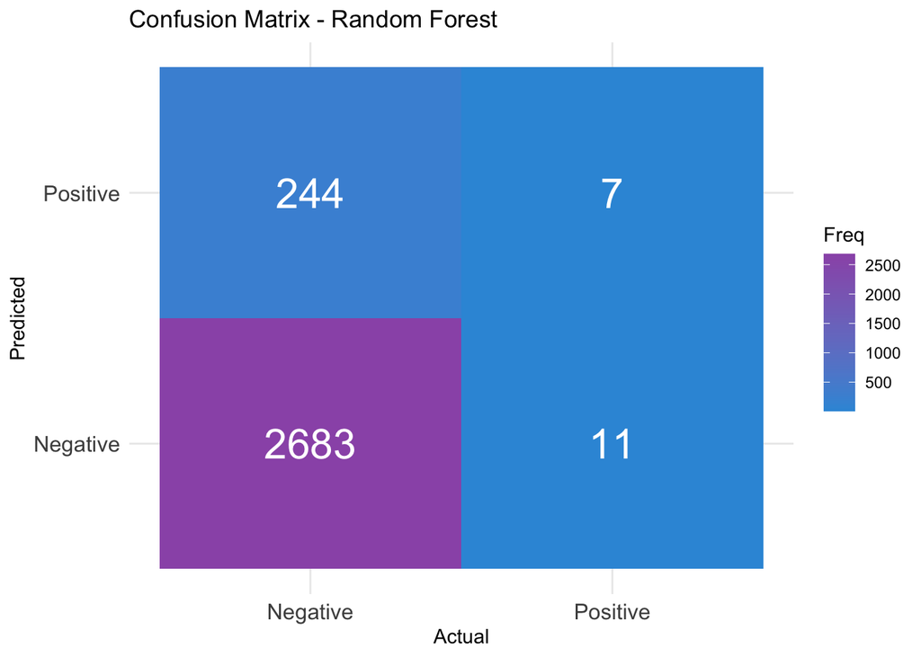

```r
# Convert confusion matrix to data frame for plotting
cm_df <- as.data.frame(cm_rf$table)

ggplot(cm_df, aes(x = Reference, y = Prediction, fill = Freq)) +
  geom_tile() +
  geom_text(aes(label = Freq), size = 8, color = "white") +
  scale_fill_gradient(low = "#3498db", high = "#9b59b6") +
  labs(title = "Confusion Matrix - Random Forest",
       x = "Actual",
       y = "Predicted") +
  theme_minimal() +
  theme(axis.text = element_text(size = 12))
```

# Tune Hyperparameters

## Key Hyperparameters

- **ntree**: Number of trees (more is usually better, but diminishing returns)
  - We’ll keep this fixed at 200 for tuning
- **mtry**: Number of features to consider at each split
  - Default for classification: sqrt(number of features)
  - **This is what we’ll tune** - we’ll test different values to find the optimal one

```r
# Set up cross-validation
cv_control <- trainControl(
  method = "cv",
  number = 10,
  classProbs = TRUE,
  summaryFunction = twoClassSummary
)

# Grid of mtry values to try
mtry_grid <- expand.grid(mtry = c(2, 4, 6, 8, 10))

# Train with cross-validation
# Note: ntree is fixed at 200; we're only tuning mtry
rf_cv <- train(
  covid19_test_results ~ .,
  data = train_data,
  method = "rf",
  trControl = cv_control,
  tuneGrid = mtry_grid,
  ntree = 200,
  metric = "ROC"
)

# View results
rf_cv
```

```
## Random Forest
##
## 100 samples
##  18 predictor
##   2 classes: 'Negative', 'Positive'
##
## No pre-processing
## Resampling: Cross-Validated (10 fold)
## Summary of sample sizes: 90, 90, 90, 90, 90, 90, ...
## Resampling results across tuning parameters:
##
##   mtry  ROC    Sens  Spec
##    2    0.716  0.82  0.50
##    4    0.724  0.64  0.56
##    6    0.712  0.60  0.56
##    8    0.658  0.60  0.56
##   10    0.672  0.54  0.60
##
## ROC was used to select the optimal model using the largest value.
## The final value used for the model was mtry = 4.
```

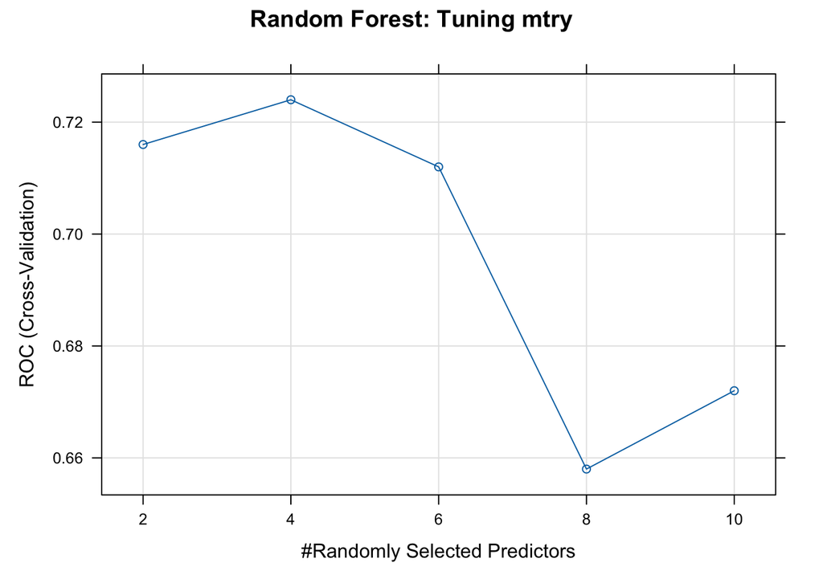

```r
# Plot mtry vs performance
plot(rf_cv, main = "Random Forest: Tuning mtry")
```

```r
cat("Best mtry:", rf_cv$bestTune$mtry, "\n")
```

```
## Best mtry: 4
```

# Summary

## What We Learned

1. ✅ **Random Forest** builds many decision trees and combines their predictions
2. ✅ **Bootstrap + feature sampling** creates diverse trees that reduce overfitting
3. ✅ **No scaling required** - trees are scale-invariant
4. ✅ **Variable importance** helps understand which features matter most
5. ✅ **OOB error** provides built-in validation estimate
6. ✅ **Cross-validation** helps tune hyperparameters like mtry
7. ✅ **Class imbalance handling** - balanced sampling for training prevents bias toward majority class

## Workshop Complete!

You’ve now learned preprocessing, unsupervised learning (K-means), and supervised learning (Random Forest)!